# Load and preprocess the data

# Are there differences in activity patterns between weekdays and weekends?

### Create a new factor variable in the dataset with two levels – “weekday” and “weekend” indicating whether a given date is a weekday or weekend day.

```r
library(plyr)
activityDOW <- mutate(imputedSteps, daytype = ifelse(weekdays(imputedSteps$date) ==
    "Saturday" | weekdays(imputedSteps$date) == "Sunday", "weekend", "weekday"))
head(activityDOW)
```

```
##        steps       date interval daytype
## 1: 1.7169811 2012-10-01        0 weekday
## 2: 0.3396226 2012-10-01        5 weekday
## 3: 0.1320755 2012-10-01       10 weekday
## 4: 0.1509434 2012-10-01       15 weekday
## 5: 0.0754717 2012-10-01       20 weekday
## 6: 2.0943396 2012-10-01       25 weekday
```

### Make a panel plot containing a time series plot (i.e. 𝚝𝚢𝚙𝚎 = “𝚕”) of the 5-minute interval (x-axis) and the average number of steps taken, averaged across all weekday days or weekend days (y-axis). See the README file in the GitHub repository to see an example of what this plot should look like using simulated data.

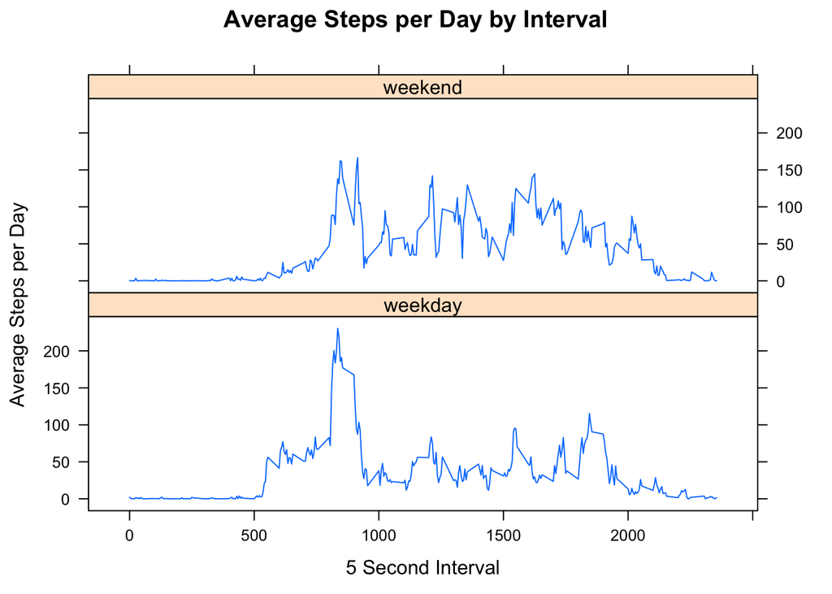

```r
dayFiveMinAve <- aggregate(steps ~ interval + daytype, activityDOW, mean)
library(lattice)
xyplot(dayFiveMinAve$steps ~ dayFiveMinAve$interval | dayFiveMinAve$daytype,
    main = "Average Steps per Day by Interval", xlab = "5 Second Interval",
    ylab = "Average Steps per Day", layout = c(1, 2), type = "l", cex = 1, cex.axis = 0.75,
    font = 2, font.lab = 2, font.main = 2, font.sub = 2, font.lab = 2)
```